# Практика 08 · Лінійна регресія

> 📖 **Теорія:** відкрий `lecture.html` у цій же теці — там інтерактивна лекція. Ця частина про те, щоб зібрати все руками.

**Що зробимо:**

1. МНК через нормальне рівняння на чистому NumPy
2. Звіримо з `scikit-learn` — має збігтися до 10⁻⁸
3. Градієнтний спуск з нуля, дослідимо роль кроку η
4. Перевіримо припущення LINE на графіку залишків

```python
import numpy as np
import matplotlib.pyplot as plt

rng = np.random.default_rng(42)

# синтетичні дані: площа будинку -> ціна
n = 60
area  = rng.uniform(80, 260, n)
price = 1.9 * area + 40 + rng.normal(0, 30, n)

print(f"{n} обʼєктів, площа {area.min():.0f}–{area.max():.0f} м², "
      f"ціна {price.min():.0f}–{price.max():.0f} тис.")
```

```
60 обʼєктів, площа 81–256 м², ціна 143–543 тис.
```

## 1. МНК руками

Нормальне рівняння: $\beta = (X^T X)^{-1} X^T y$

Стовпець одиниць у матриці $X$ — це і є вільний член $\beta_0$.

```python
def fit_ols(x, y):
    """Нормальне рівняння. Повертає (beta_0, beta_1)."""
    X = np.c_[np.ones_like(x), x]          # [1, x]
    # solve надійніший за inv: не обертає матрицю явно
    return np.linalg.solve(X.T @ X, X.T @ y)

b0, b1 = fit_ols(area, price)
print(f"beta_0 = {b0:8.3f}   (вільний член)")
print(f"beta_1 = {b1:8.3f}   (ціна за 1 м²)")
```

```
beta_0 =   35.295   (вільний член)
beta_1 =    1.891   (ціна за 1 м²)
```

### Метрики

Порахуємо все, про що йшлося в лекції.

```python
def metrics(y, y_hat):
    resid = y - y_hat
    mse = np.mean(resid ** 2)
    return {
        "MSE":  mse,
        "RMSE": np.sqrt(mse),
        "MAE":  np.mean(np.abs(resid)),
        "R2":   1 - np.sum(resid ** 2) / np.sum((y - y.mean()) ** 2),
    }

pred = b0 + b1 * area
for k, v in metrics(price, pred).items():
    print(f"{k:>5} = {v:10.3f}")

# baseline: завжди прогнозуємо середнє
print(f"\nR2 моделі-середнього = {metrics(price, np.full_like(price, price.mean()))['R2']:.3f}")
```

```
  MSE =    503.293
 RMSE =     22.434
  MAE =     18.641
   R2 =      0.948

R2 моделі-середнього = 0.000
```

## 2. Звірка зі scikit-learn

Якщо все правильно — різниця буде на рівні похибки округлення.

```python
from sklearn.linear_model import LinearRegression

sk = LinearRegression().fit(area.reshape(-1, 1), price)

print(f"наш   : b0={b0:.6f}  b1={b1:.6f}")
print(f"sklearn: b0={sk.intercept_:.6f}  b1={sk.coef_[0]:.6f}")
print(f"різниця: {abs(b0 - sk.intercept_):.2e}, {abs(b1 - sk.coef_[0]):.2e}")

assert np.allclose([b0, b1], [sk.intercept_, sk.coef_[0]]), "розрахунок розійшовся!"
print("\n✅ збігається")
```

```
наш   : b0=35.294513  b1=1.891316
sklearn: b0=35.294513  b1=1.891316
різниця: 1.05e-12, 5.55e-15

✅ збігається
```

## 3. Градієнтний спуск з нуля

Градієнт MSE по коефіцієнтах:

$$\nabla L = \frac{2}{n} X^T (X\beta - y)$$

**Важливо:** ознаку треба стандартизувати. Інакше β₀ і β₁ живуть у різних масштабах, поверхня втрат витягується у вузький «яр», і спуск застрягає.

```python
def gradient_descent(x, y, eta=0.1, steps=100):
    """Повертає (шлях коефіцієнтів, історія втрат) у стандартизованих координатах."""
    xs = (x - x.mean()) / x.std()
    X = np.c_[np.ones_like(xs), xs]
    beta = np.zeros(2)
    path, hist = [beta.copy()], []
    for _ in range(steps):
        grad = 2 / len(y) * X.T @ (X @ beta - y)
        beta = beta - eta * grad
        path.append(beta.copy())
        hist.append(np.mean((y - X @ beta) ** 2))
    return np.array(path), np.array(hist)


# опорне значення: точний мінімум у тих самих координатах
areas_s = (area - area.mean()) / area.std()
mse_opt = metrics(price, np.c_[np.ones(n), areas_s] @ fit_ols(areas_s, price))["MSE"]
print(f"мінімум MSE = {mse_opt:.2f}\n")

for eta in [0.001, 0.01, 0.1, 0.5, 1.01]:
    _, hist = gradient_descent(area, price, eta=eta, steps=60)
    final = hist[-1]
    if not np.isfinite(final) or final > hist[0]:
        verdict = "💥 розбіжність"
    elif final > mse_opt * 1.1:
        verdict = "🐌 не встигло"
    else:
        verdict = "✅ збіглося"
    shown = f"{final:12.2f}" if np.isfinite(final) else "         inf"
    print(f"eta={eta:<6} MSE={shown}   {verdict}")
```

```
мінімум MSE = 503.29

eta=0.001  MSE=   111662.60   🐌 не встигло
eta=0.01   MSE=    13017.69   🐌 не встигло
eta=0.1    MSE=      503.29   ✅ збіглося
eta=0.5    MSE=      503.29   ✅ збіглося
eta=1.01   MSE=  1522106.78   💥 розбіжність
```

### Криві навчання

Видно, як крок визначає і швидкість, і саму можливість збіжності.

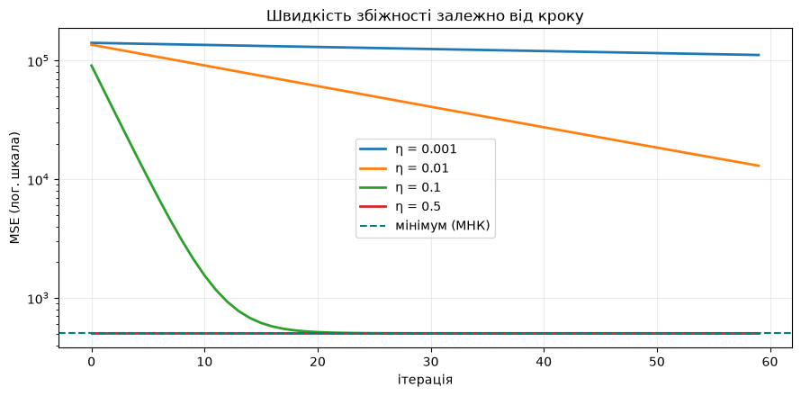

```python
fig, ax = plt.subplots(figsize=(9, 4.5))

for eta in [0.001, 0.01, 0.1, 0.5]:
    _, hist = gradient_descent(area, price, eta=eta, steps=60)
    ax.plot(hist, label=f"η = {eta}", lw=2)

ax.axhline(mse_opt, color="teal", ls="--", lw=1.5, label="мінімум (МНК)")
ax.set_yscale("log")
ax.set_xlabel("ітерація"); ax.set_ylabel("MSE (лог. шкала)")
ax.set_title("Швидкість збіжності залежно від кроку")
ax.legend(); ax.grid(alpha=.25)
plt.tight_layout(); plt.show()
```

## 4. Перевірка припущень: графік залишків

Головний діагностичний інструмент. У здоровій моделі залишки — **безструктурна хмара навколо нуля**. Будь-який візерунок = модель щось не побачила.

Порівняємо чотири сценарії з лекції.

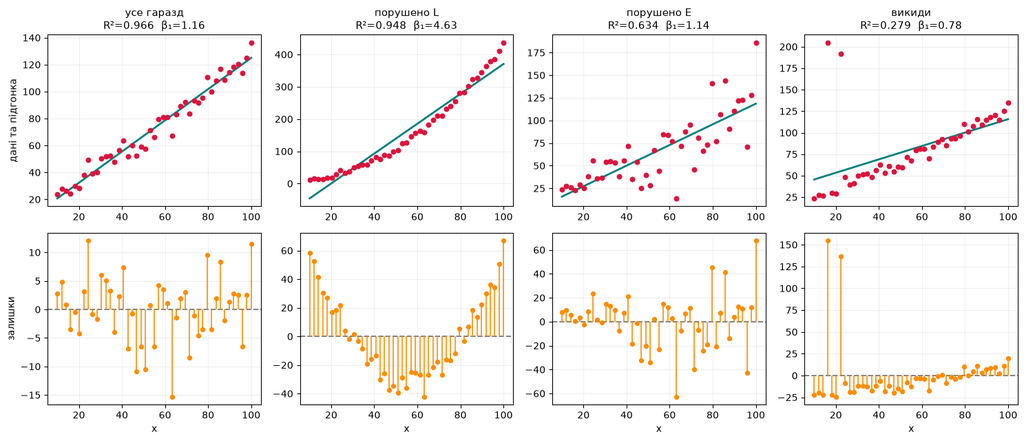

```
Зверни увагу: у сценарії 'порушено L' R² високий, але залишки лягли дугою.
Одна метрика ніколи не скаже всієї правди — дивись на залишки.
```

```python
def make_case(kind, seed=7):
    r = np.random.default_rng(seed)
    x = np.linspace(10, 100, 45)
    if kind == "ok":
        y = 12 + 1.15 * x + r.normal(0, 7, x.size)
    elif kind == "curve":
        y = 8 + 0.042 * x ** 2 + r.normal(0, 7, x.size)
    elif kind == "funnel":
        y = 12 + 1.15 * x + r.normal(0, 1, x.size) * (1.6 + x * 0.42)
    elif kind == "outlier":
        y = 12 + 1.15 * x + r.normal(0, 6, x.size)
        y[[3, 6]] = [205, 192]
    return x, y


cases = [("ok", "усе гаразд"), ("curve", "порушено L"),
         ("funnel", "порушено E"), ("outlier", "викиди")]

fig, axes = plt.subplots(2, 4, figsize=(15, 6.5))
for col, (kind, title) in enumerate(cases):
    x, y = make_case(kind)
    c0, c1 = fit_ols(x, y)
    yh = c0 + c1 * x
    res = y - yh
    r2 = metrics(y, yh)["R2"]

    top = axes[0, col]
    top.scatter(x, y, s=22, color="crimson", zorder=3)
    top.plot(x, yh, color="teal", lw=2)
    top.set_title(f"{title}\nR²={r2:.3f}  β₁={c1:.2f}", fontsize=11)
    top.grid(alpha=.2)

    bot = axes[1, col]
    bot.axhline(0, color="gray", ls="--", lw=1.4)
    bot.vlines(x, 0, res, color="darkorange", lw=1.2)
    bot.scatter(x, res, s=18, color="darkorange", zorder=3)
    bot.set_xlabel("x"); bot.grid(alpha=.2)
    if col == 0:
        top.set_ylabel("дані та підгонка"); bot.set_ylabel("залишки")

plt.tight_layout(); plt.show()

print("Зверни увагу: у сценарії 'порушено L' R² високий, але залишки лягли дугою.")
print("Одна метрика ніколи не скаже всієї правди — дивись на залишки.")
```

## 💻 Завдання

### 🟢 Рівень 1 — разом

1. Зміни `rng.normal(0, 30, n)` на більший шум. Як падає R²? Чи змінюються коефіцієнти?
2. Побудуй графік залишків для основних даних (`area`, `price`). Чи є візерунок?

### 🔴 Рівень 3 — виклик

1. Додай L2-регуляризацію: $\beta = (X^TX + \lambda I)^{-1}X^Ty$. Побудуй графік коефіцієнтів від λ. Не штрафуй вільний член!
2. Візьми датасет із Kaggle, застосуй увесь пайплайн і перевір усі чотири припущення LINE. Що порушено і як це виправити?

## 🧪 Самоперевірка

**1. Чому `np.linalg.solve` кращий за `np.linalg.inv`?**

**відповідь**

Явне обертання матриці дорожче й чисельно менш стійке. `solve` розкладає матрицю й розвʼязує систему напряму — точніше, особливо коли матриця погано обумовлена.

**2. R² моделі дорівнює −0.4. Що це означає?**

**відповідь**

Модель гірша за просте прогнозування середнім. Найчастіше — груба помилка (переплутані ознаки, оцінка на інших даних, забута стандартизація).

**3. Навіщо стандартизувати ознаки перед градієнтним спуском, якщо для МНК це не треба?**

**відповідь**

МНК розвʼязує рівняння точно, масштаб не заважає. Градієнтний спуск іде по поверхні втрат: за різних масштабів ознак вона витягується у вузький «яр», і єдиний спільний крок η або завеликий для однієї осі, або замалий для іншої.